# More Guns, Less Crime?

Viola Group

8/02/2018

```r
knitr::opts_chunk$set(
    echo = TRUE,
    message = FALSE,
    warning = FALSE
)
options(scipen =10, show.signif.stars = FALSE)
```

# Guns dataset from the “AER”" package.

- **Dataset is a balanced panel of data on 50 US states, plus the District of Columbia (for a total of 51 states), by year for 1977–1999, and contains 1,173 observations on 13 variables. The variables are:**
  - *state:* factor indicating state.
  - *year:* factor indicating year.
  - *violent:* violent crime rate (incidents per 100,000 members of the population).
  - *murder:* murder rate (incidents per 100,000).
  - *robbery:* robbery rate (incidents per 100,000).
  - *prisoners:* incarceration rate in the state in the previous year (sentenced prisoners per 100,000 residents;value for the previous year).
  - *afam:* percent of state population that is African-American, ages 10 to 64.
  - *cauc:* percent of state population that is Caucasian, ages 10 to 64.
  - *male:* percent of state population that is male, ages 10 to 29.
  - *population:* state population, in millions of people.
  - *income:* real per capita personal income in the state (US dollars).
  - *density:* population per square mile of land area, divided by 1,000.
  - *law:* factor. Does the state have a shall carry law in effect in that year?

## Objective: Identify the predictors of violence.

**Install and load the AER Package**

```r
#install.packages("AER", repos = "http://cran.us.r-project.org", type = "source")
library("AER")
```

**Load the *Guns* dataset from the AER Package**

```r
data("Guns")
```

**Examine the structure and summary of the *Guns* dataset**

```r
str(Guns)  #print the structure
```

```
## 'data.frame':    1173 obs. of  13 variables:
##  $ year      : Factor w/ 23 levels "1977","1978",..: 1 2 3 4 5 6 7 8 9 10 ...
##  $ violent   : num  414 419 413 448 470 ...
##  $ murder    : num  14.2 13.3 13.2 13.2 11.9 10.6 9.2 9.4 9.8 10.1 ...
##  $ robbery   : num  96.8 99.1 109.5 132.1 126.5 ...
##  $ prisoners : int  83 94 144 141 149 183 215 243 256 267 ...
##  $ afam      : num  8.38 8.35 8.33 8.41 8.48 ...
##  $ cauc      : num  55.1 55.1 55.1 54.9 54.9 ...
##  $ male      : num  18.2 18 17.8 17.7 17.7 ...
##  $ population: num  3.78 3.83 3.87 3.9 3.92 ...
##  $ income    : num  9563 9932 9877 9541 9548 ...
##  $ density   : num  0.0746 0.0756 0.0762 0.0768 0.0772 ...
##  $ state     : Factor w/ 51 levels "Alabama","Alaska",..: 1 1 1 1 1 1 1 1 1 1 ...
##  $ law       : Factor w/ 2 levels "no","yes": 1 1 1 1 1 1 1 1 1 1 ...
```

```r
summary(Guns)  #Identify the missing values
```

```
##       year        violent           murder          robbery
##  1977   : 51   Min.   :  47.0   Min.   : 0.200   Min.   :   6.4
##  1978   : 51   1st Qu.: 283.1   1st Qu.: 3.700   1st Qu.:  71.1
##  1979   : 51   Median : 443.0   Median : 6.400   Median : 124.1
##  1980   : 51   Mean   : 503.1   Mean   : 7.665   Mean   : 161.8
##  1981   : 51   3rd Qu.: 650.9   3rd Qu.: 9.800   3rd Qu.: 192.7
##  1982   : 51   Max.   :2921.8   Max.   :80.600   Max.   :1635.1
##  (Other):867
##    prisoners           afam              cauc            male
##  Min.   :  19.0   Min.   : 0.2482   Min.   :21.78   Min.   :12.21
##  1st Qu.: 114.0   1st Qu.: 2.2022   1st Qu.:59.94   1st Qu.:14.65
##  Median : 187.0   Median : 4.0262   Median :65.06   Median :15.90
##  Mean   : 226.6   Mean   : 5.3362   Mean   :62.95   Mean   :16.08
##  3rd Qu.: 291.0   3rd Qu.: 6.8507   3rd Qu.:69.20   3rd Qu.:17.53
##  Max.   :1913.0   Max.   :26.9796   Max.   :76.53   Max.   :22.35
##
##    population          income         density                 state
##  Min.   : 0.4027   Min.   : 8555   Min.   : 0.000707   Alabama   :  23
##  1st Qu.: 1.1877   1st Qu.:11935   1st Qu.: 0.031911   Alaska    :  23
##  Median : 3.2713   Median :13402   Median : 0.081569   Arizona   :  23
##  Mean   : 4.8163   Mean   :13725   Mean   : 0.352038   Arkansas  :  23
##  3rd Qu.: 5.6856   3rd Qu.:15271   3rd Qu.: 0.177718   California:  23
##  Max.   :33.1451   Max.   :23647   Max.   :11.102120   Colorado  :  23
##                                                        (Other)   :1035
##   law
##  no :888
##  yes:285
##
##
##
##
##
```

**Explanation:** Based on the data summary, none of the variables appear to have missing values.

**Identify the column number associated with each variable**

```r
names(Guns)
```

```
##  [1] "year"       "violent"    "murder"     "robbery"    "prisoners"
##  [6] "afam"       "cauc"       "male"       "population" "income"
## [11] "density"    "state"      "law"
```

## Explore the distribution of the violent crime rate

```r
x <- sort(Guns$violent)
m <- mean(Guns$violent)
std <- sd(Guns$violent)
```

**Plots of the violent crime rate**

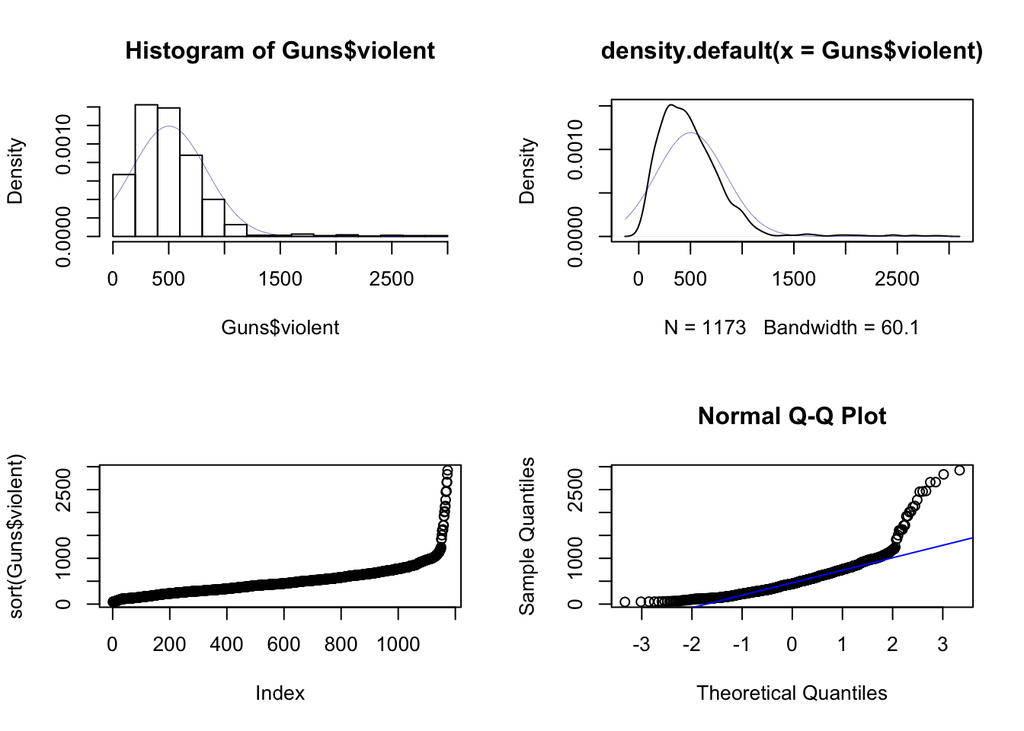

```r
old <- par(mfrow=c(2,2))
#Price Histogram
hist(Guns$violent, freq=FALSE)
curve(dnorm(x, mean=m, sd=std), col="darkblue", lwd=0.25,add = TRUE)

#Density Plot
plot(density(Guns$violent))
curve(dnorm(x, mean=m, sd=std), col="darkblue", lwd=0.25,add = TRUE)

#Sortplot
plot(sort(Guns$violent))

#QQ-Plot
qqnorm(Guns$violent)
qqline(Guns$violent, col="blue")
```

**Explanation** After examining the above plots, the *violent* variable does not appear to be normally distributed. In the histogram, the distribution of the *violent* variable deviates from the normal distribution. Aditionally, the actual values of the *violent* varibale do not adhere to the blue QQ-line on the the QQ-Plot. The *violent* variable is skewed to the right (positively skewed) and the mean (503.074) > median (443). On the Sort Plot there appears to be a few clusters on the right side of the plot, where the violent crime rate is high. Based on the fact that the *violent* variable is skewed to the right I would consider the use a “log()” transformation on this variable. The “log()” transformation could reduce the skewness, which in turn could make it easier to interpret whether or not a relationship exist between variables that might not have otherwise been obvious.

```r
par(old)
```

## Examine the Scatterplot Matrix of the dataset

**Plot the scatterplot matrix excluding the factor variables *year* and *state*.**

```r
library("GGally") #load GGally package
```

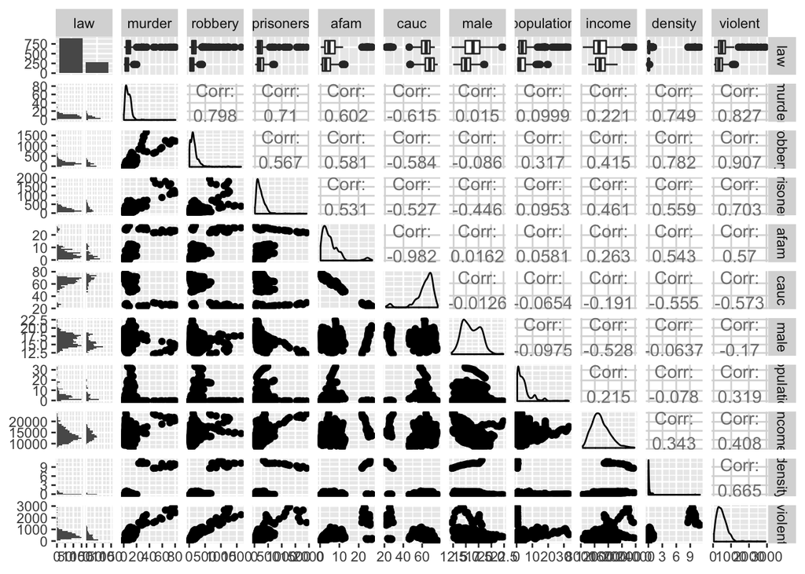

```r
ggpairs(Guns, columns = c(13, 3:11, 2))
```

**Add colors to the scatterplot matrix to see how the factor variable *law* effects other variables.**

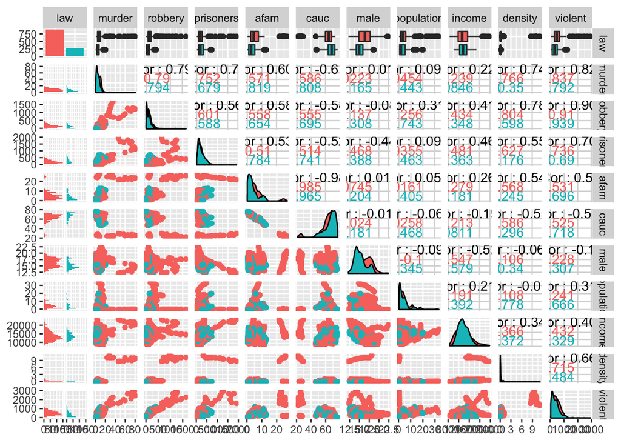

```r
ggpairs(Guns, columns = c(13, 3:11, 2), mapping = aes(color = law))
```

**Explanation** Based on the ggpairs scatterplot, the variables *murder* and *robbery* have the strongest positive linear relationship with the violent crime rate, with a correlation value of 0.827 and 0.907 respectively. Considering these variables are components of the violent crime rate, we expected there to be high correlation values. However with that being said, these variables are more of a subcategory of violent crimes and therefore aren’t good predictors for a linear model. Other variables that showed a high correlation value were prisoners (0.703), density (0.665), afam (0.57), cauc(-0.573), and income (0.408). The law variable was also a good indicator because the box plot showed that on average states that have a shall carry law in effect have a lower violent crime rate as well as as a lower murder and robbery rate.

## Examination of Multiple Regression model

```r
m1 <- lm(violent~., data = Guns)
modm1 <- fortify(m1)
summary(m1)
```

```
##
## Call:
## lm(formula = violent ~ ., data = Guns)
##
## Residuals:
##      Min       1Q   Median       3Q      Max
## -185.644  -28.942   -1.771   25.072  275.394
##
## Coefficients:
##                              Estimate  Std. Error t value Pr(>|t|)
## (Intercept)                257.806162  167.391563   1.540 0.123817
## year1978                    13.839537    9.958958   1.390 0.164917
## year1979                    33.719798   10.152885   3.321 0.000926
## year1980                    35.930098   10.422555   3.447 0.000588
## year1981                    33.268371   10.834207   3.071 0.002189
## year1982                    41.773198   11.324775   3.689 0.000237
## year1983                    42.516005   12.065711   3.524 0.000443
## year1984                    62.836355   13.303894   4.723 2.62e-06
## year1985                    77.153161   14.545416   5.304 1.37e-07
## year1986                    93.961159   15.974462   5.882 5.39e-09
## year1987                    98.752360   17.412917   5.671 1.82e-08
## year1988                   114.959787   19.063674   6.030 2.24e-09
## year1989                   122.089056   20.607492   5.924 4.20e-09
## year1990                   166.985142   25.278322   6.606 6.17e-11
## year1991                   174.522050   26.557788   6.571 7.71e-11
## year1992                   194.199123   28.016728   6.932 7.11e-12
## year1993                   200.629640   29.106194   6.893 9.23e-12
## year1994                   192.383270   30.420465   6.324 3.71e-10
## year1995                   183.995074   31.709355   5.803 8.55e-09
## year1996                   164.912568   32.887234   5.014 6.20e-07
## year1997                   166.495955   34.031544   4.892 1.15e-06
## year1998                   154.454835   35.385533   4.365 1.39e-05
## year1999                   136.573284   36.639499   3.727 0.000203
## murder                       7.517483    0.656946  11.443  < 2e-16
## robbery                      1.303426    0.036435  35.774  < 2e-16
## prisoners                    0.263372    0.033309   7.907 6.43e-15
## afam                       -24.921994    8.189525  -3.043 0.002397
## cauc                        -5.893595    2.789860  -2.113 0.034870
## male                        21.545622    5.582260   3.860 0.000120
## population                   7.029439    2.816530   2.496 0.012715
```

[output cut: 42 more lines]

```
## stateSouth Dakota         -203.140954   36.125859  -5.623 2.38e-08
## stateTennessee             -43.347247   22.914213  -1.892 0.058793
## stateTexas                -208.368328   45.323036  -4.597 4.78e-06
## stateUtah                 -204.624695   46.306181  -4.419 1.09e-05
## stateVermont              -215.010344   45.105243  -4.767 2.12e-06
## stateVirginia             -198.054009   21.460380  -9.229  < 2e-16
## stateWashington            -68.125930   34.090751  -1.998 0.045925
## stateWest Virginia        -208.072281   40.028432  -5.198 2.40e-07
## stateWisconsin            -266.551246   38.952373  -6.843 1.29e-11
## stateWyoming              -133.177059   41.877387  -3.180 0.001513
## lawyes                     -19.012545    6.095426  -3.119 0.001861
##
## Residual standard error: 49.54 on 1090 degrees of freedom
## Multiple R-squared:  0.9796, Adjusted R-squared:  0.978
## F-statistic: 637.5 on 82 and 1090 DF,  p-value: < 2.2e-16
```

### How well does the Model Fit?

**Fitted Plot**

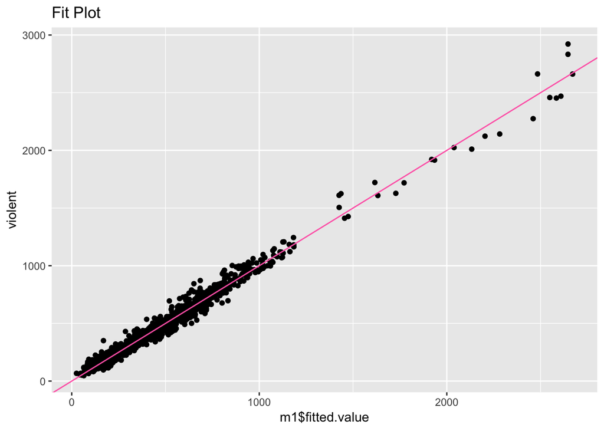

```r
library(ggplot2) #load ggplot 2 package
qplot(m1$fitted.value, violent, data=Guns) +
geom_abline(intercept = 0, slope = 1, color="hot pink") +
ggtitle("Fit Plot")
```

**Residuals vs. Fitted**

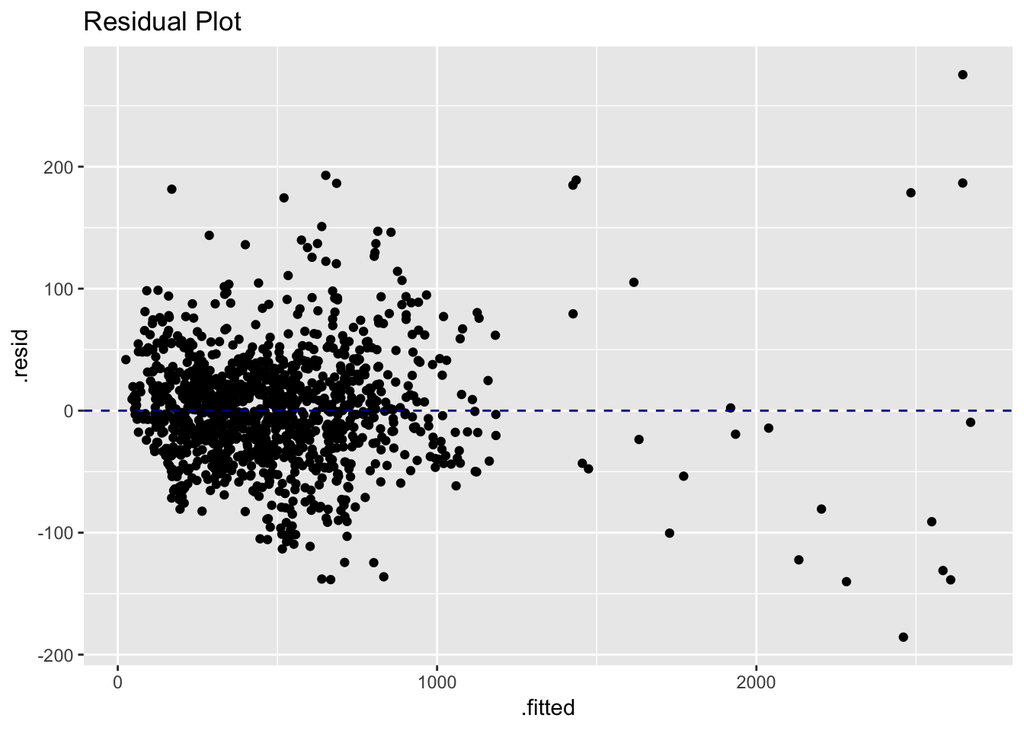

```r
ggplot(m1, aes(.fitted, .resid)) +
geom_point() +
geom_hline(yintercept=0, color="dark blue", linetype="dashed") +
ggtitle("Residual Plot")
```

**Create another model using log(violent)**

```r
m2 <- lm(log(violent)~., data = Guns)
modm2 <- fortify(m2)
summary(m2)
```

```
##
## Call:
## lm(formula = log(violent) ~ ., data = Guns)
##
## Residuals:
##      Min       1Q   Median       3Q      Max
## -0.45373 -0.06535  0.00254  0.06647  0.66584
##
## Coefficients:
##                               Estimate   Std. Error t value
## (Intercept)                3.976306586  0.424762991   9.361
## year1978                   0.048000725  0.025271267   1.899
## year1979                   0.128347393  0.025763364   4.982
## year1980                   0.149663268  0.026447663   5.659
## year1981                   0.135423056  0.027492247   4.926
## year1982                   0.130421163  0.028737084   4.538
## year1983                   0.113652690  0.030617239   3.712
## year1984                   0.156592443  0.033759180   4.639
## year1985                   0.201694089  0.036909592   5.465
## year1986                   0.264128792  0.040535855   6.516
## year1987                   0.269970143  0.044185994   6.110
## year1988                   0.315507008  0.048374858   6.522
## year1989                   0.351863628  0.052292359   6.729
## year1990                   0.423336576  0.064144784   6.600
## year1991                   0.455036654  0.067391482   6.752
## year1992                   0.486599578  0.071093601   6.844
## year1993                   0.506120184  0.073858167   6.853
## year1994                   0.496287766  0.077193184   6.429
## year1995                   0.488073887  0.080463795   6.066
## year1996                   0.445653546  0.083452711   5.340
## year1997                   0.441277703  0.086356446   5.110
## year1998                   0.401764163  0.089792248   4.474
## year1999                   0.351141628  0.092974240   3.777
## murder                    -0.000177748  0.001667029  -0.107
## robbery                    0.001372765  0.000092455  14.848
## prisoners                  0.000236498  0.000084523   2.798
## afam                       0.022022912  0.020781258   1.060
## cauc                       0.011637306  0.007079384   1.644
## male                       0.057211045  0.014165214   4.039
## population                -0.004834415  0.007147061  -0.676
```

[output cut: 126 more lines]

```
## stateSouth Dakota                 < 2e-16
## stateTennessee                   0.853442
## stateTexas                       0.896305
## stateUtah                 0.0000000839495
## stateVermont                      < 2e-16
## stateVirginia                     < 2e-16
## stateWashington                  0.072907
## stateWest Virginia                < 2e-16
## stateWisconsin                    < 2e-16
## stateWyoming              0.0000000826526
## lawyes                           0.002014
##
## Residual standard error: 0.1257 on 1090 degrees of freedom
## Multiple R-squared:  0.9648, Adjusted R-squared:  0.9621
## F-statistic: 363.8 on 82 and 1090 DF,  p-value: < 2.2e-16
```

**Log Transformation Fitted Plot**

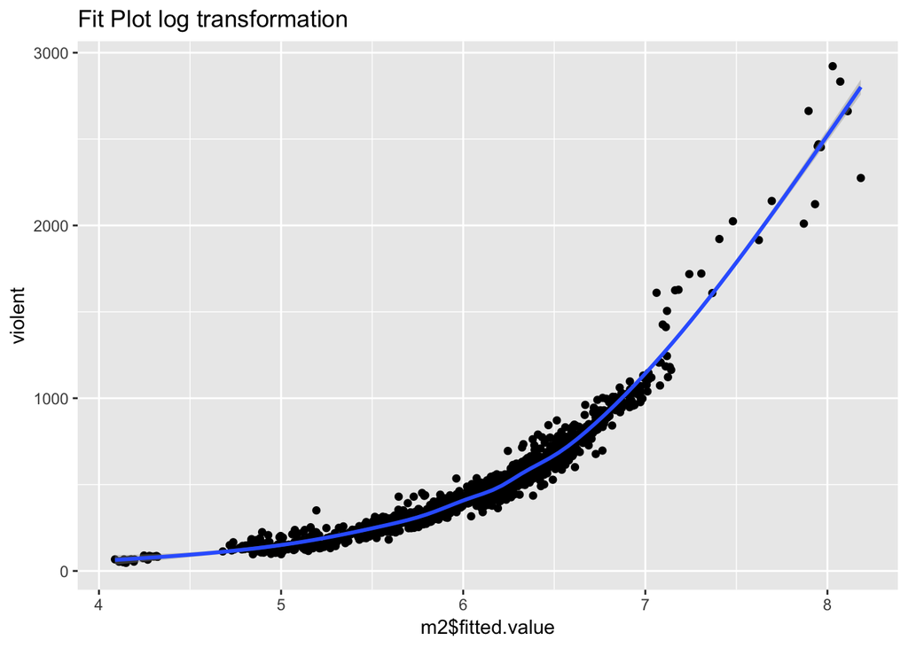

```r
qplot(m2$fitted.value, violent, data=Guns) +geom_smooth() +ggtitle("Fit Plot log transformation")
```

**Log Transformation Residuals vs. Fitted**

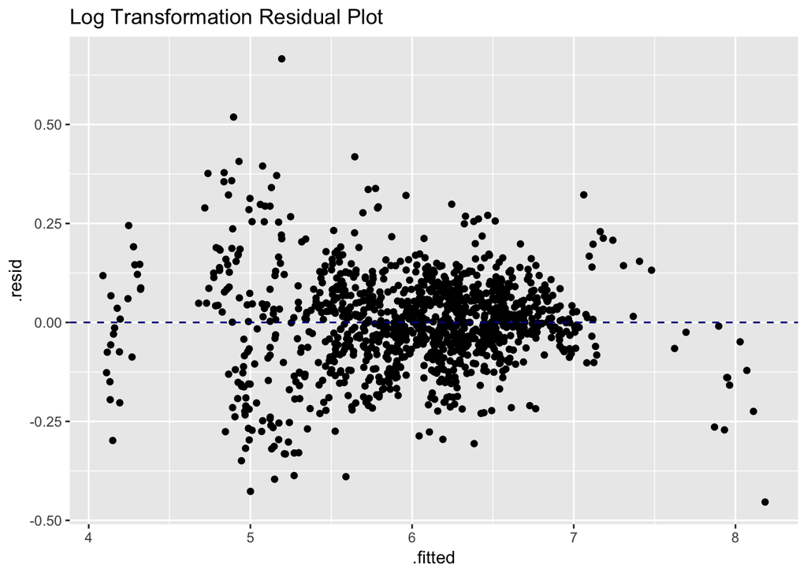

```r
ggplot(m2, aes(.fitted, .resid)) +
geom_point() +
geom_hline(yintercept=0, color="dark blue", linetype="dashed") +
ggtitle("Log Transformation Residual Plot")
```

**Box-Cox Transformation**

```r
library(car)
(lambda <- powerTransform(m1))
```

```
## Estimated transformation parameter
##        Y1
## 0.6022324
```

```r
lam <- lambda$lambda
mlam <- lm(violent^lam ~ ., Guns)
modlam <- fortify(mlam)
```

**Box-Cox Transformation Fitted Plot**

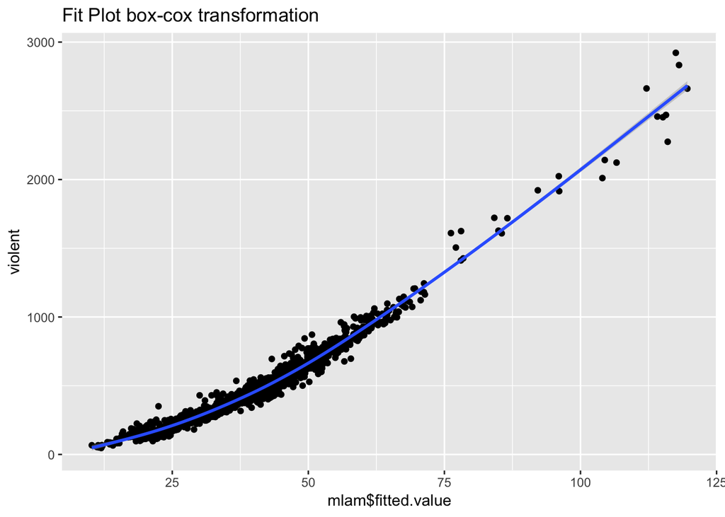

```r
qplot(mlam$fitted.value, violent, data=Guns) +geom_smooth() +ggtitle("Fit Plot box-cox transformation")
```

**Box-Cox Transformation Residuals vs. Fitted**

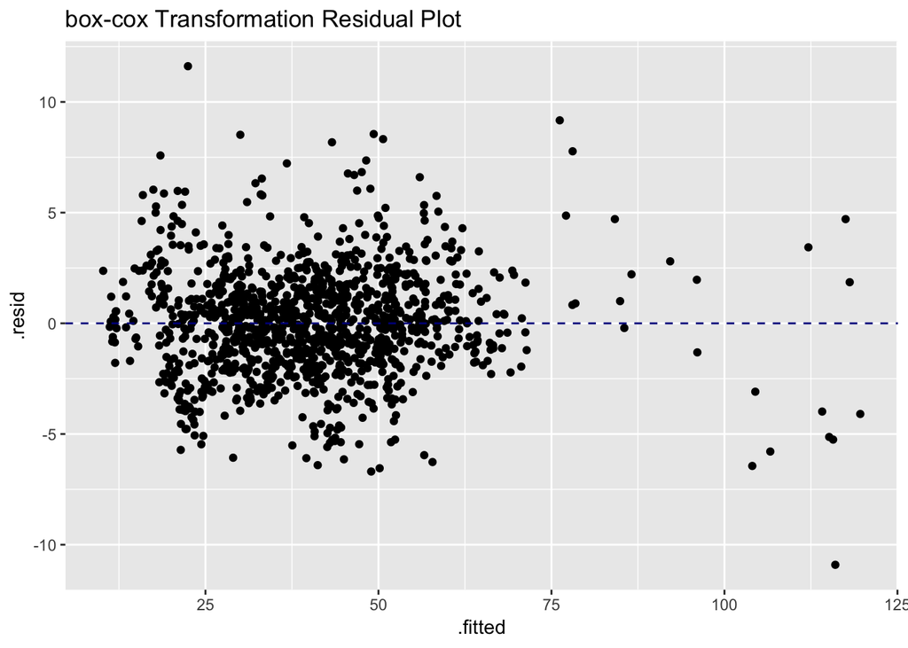

```r
ggplot(mlam, aes(.fitted, .resid)) +
geom_point() +
geom_hline(yintercept=0, color="dark blue", linetype="dashed") +
ggtitle("box-cox Transformation Residual Plot")
```

### Normal QQ-plots for detecting nonnormality

```r
library(gridExtra) #load gridExtra Library
```

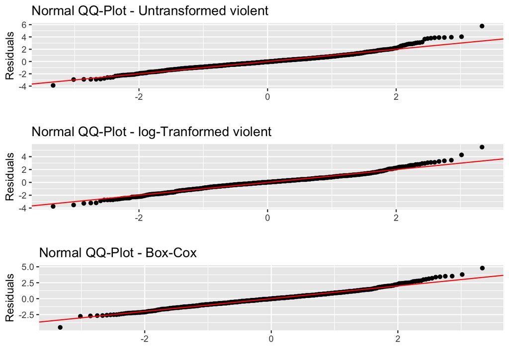

```r
p1 <- qplot(sample = scale(.resid), data = modm1) + geom_abline(intercept = 0,
slope = 1, color = "red") + labs(title = "Normal QQ-Plot - Untransformed violent", y = "Residuals")
p2 <- qplot(sample = scale(.resid), data = modm2) + geom_abline(intercept = 0,
slope = 1, color = "red") + labs(title = "Normal QQ-Plot - log-Tranformed violent", y = "Residuals")
p3 <- qplot(sample = scale(.resid), data = modlam) + geom_abline(intercept = 0,
slope = 1, color = "red") + labs(title = "Normal QQ-Plot - Box-Cox", y = "Residuals")
grid.arrange(p1, p2, p3, nrow = 3)
```

*The Box-Cox Transformed model appears look the best out of the 3 models, although there isnt much separation.

### Histogram

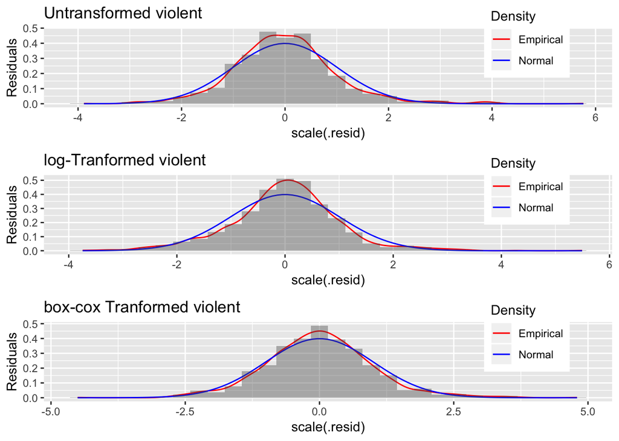

```r
p4 <- qplot(scale(.resid), data = modm1, geom = "blank") + geom_line(aes(y = ..density..,
colour = "Empirical"), stat = "density") + stat_function(fun = dnorm, aes(colour = "Normal")) + geom_histogram(aes(y = ..density..), alpha = 0.4) + scale_colour_manual(name = "Density", values = c("red", "blue")) + theme(legend.position = c(0.85, 0.85)) + labs(title = "Untransformed violent", y = "Residuals")

p5 <- qplot(scale(.resid), data = modm2, geom = "blank") + geom_line(aes(y = ..density..,
colour = "Empirical"), stat = "density") + stat_function(fun = dnorm, aes(colour = "Normal"))+ geom_histogram(aes(y = ..density..), alpha = 0.4) + scale_colour_manual(name = "Density", values = c("red", "blue")) + theme(legend.position = c(0.85, 0.85)) + labs(title = "log-Tranformed violent", y = "Residuals")

p6 <- qplot(scale(.resid), data = modlam, geom = "blank") + geom_line(aes(y = ..density..,
colour = "Empirical"), stat = "density") + stat_function(fun = dnorm, aes(colour = "Normal"))+ geom_histogram(aes(y = ..density..), alpha = 0.4) + scale_colour_manual(name = "Density", values = c("red", "blue")) + theme(legend.position = c(0.85, 0.85)) + labs(title = "box-cox Tranformed violent", y = "Residuals")
grid.arrange(p4, p5, p6, nrow = 3)
```

*The residuals of the Box-Cox Transformed model appears to have the most normally distributed histogram.

**Shapiro test of Normality**

```r
shapiro.test(residuals(m1))
```

```
##
##  Shapiro-Wilk normality test
##
## data:  residuals(m1)
## W = 0.97023, p-value = 8.514e-15
```

```r
shapiro.test(residuals(m2))
```

```
##
##  Shapiro-Wilk normality test
##
## data:  residuals(m2)
## W = 0.97727, p-value = 0.000000000001293
```

```r
shapiro.test(residuals(mlam))
```

```
##
##  Shapiro-Wilk normality test
##
## data:  residuals(mlam)
## W = 0.98664, p-value = 0.00000000698
```

**Explanation:**The Shapiro-Wilk test indicates the Pearson correlation between the residuals and the normal quantiles, W is equal to 0.97023, 097727, and 0.98664 for the untransformed, log-transformed, and box-cox transformed models respectively.

**Based on our analysis we will presume with the box-cox transformed model**

## Model section: Stepwise regression

**Use the automated function to filter out, which variables are the most effective predictors in the box-cox transformed model.**

```r
m3 <- step(mlam)
```

```
## Start:  AIC=2239.81
## violent^lam ~ year + murder + robbery + prisoners + afam + cauc +
##     male + population + income + density + state + law
##
##              Df Sum of Sq   RSS    AIC
## - cauc        1         0  6872 2237.8
## - density     1         0  6873 2237.9
## - afam        1         6  6879 2238.9
## - population  1         7  6879 2239.0
## - income      1         8  6880 2239.2
## <none>                     6872 2239.8
## - law         1        78  6950 2251.0
## - male        1       100  6972 2254.7
## - murder      1       132  7005 2260.2
## - prisoners   1       218  7090 2274.4
## - year       22      1632  8504 2445.7
## - robbery     1      4594 11467 2838.3
## - state      50     33830 40702 4226.3
##
## Step:  AIC=2237.81
## violent^lam ~ year + murder + robbery + prisoners + afam + male +
##     population + income + density + state + law
##
##              Df Sum of Sq   RSS    AIC
## - density     1         0  6873 2235.9
## - population  1         8  6880 2237.1
## - income      1         8  6881 2237.2
## <none>                     6872 2237.8
## - afam        1        16  6888 2238.5
## - law         1        78  6951 2249.1
## - murder      1       133  7006 2258.3
## - male        1       194  7066 2268.4
## - prisoners   1       231  7104 2274.6
## - year       22      1825  8697 2470.0
## - robbery     1      4595 11467 2836.4
## - state      50     33910 40782 4226.6
##
## Step:  AIC=2235.88
## violent^lam ~ year + murder + robbery + prisoners + afam + male +
##     population + income + state + law
```

[output cut: 29 more lines]

```
##
## Step:  AIC=2234.63
## violent^lam ~ year + murder + robbery + prisoners + afam + male +
##     state + law
##
##             Df Sum of Sq   RSS    AIC
## <none>                    6889 2234.6
## - afam       1        15  6904 2235.1
## - law        1        89  6978 2247.7
## - murder     1       172  7061 2261.5
## - male       1       206  7095 2267.2
## - prisoners  1       455  7344 2307.7
## - year      22      1844  8733 2468.9
## - robbery    1      4688 11577 2841.6
## - state     50     48242 55131 4574.2
```

- **Based on the stepwise function the most optimal model is:
  - $violent^lam ~ year + murder + robbery + prisoners + afam + male + state + law$

**Compare Coefficients of the two models**

```r
compareCoefs(mlam, m3, se = FALSE)
```

```
## Calls:
## 1: lm(formula = violent^lam ~ ., data = Guns)
## 2: lm(formula = violent^lam ~ year + murder + robbery + prisoners +
##   afam + male + state + law, data = Guns)
##
##                            Model 1  Model 2
## (Intercept)                   11.3     11.6
## year1978                     0.886    0.955
## year1979                      2.32     2.39
## year1980                      2.65     2.67
## year1981                      2.41     2.45
## year1982                      2.57     2.60
## year1983                      2.32     2.39
## year1984                      3.26     3.42
## year1985                      4.14     4.35
## year1986                      5.33     5.58
## year1987                      5.46     5.75
## year1988                      6.41     6.74
## year1989                      6.99     7.36
## year1990                      8.93     9.30
## year1991                      9.55     9.90
## year1992                      10.3     10.7
## year1993                      10.7     11.1
## year1994                      10.3     10.8
## year1995                      9.96    10.41
## year1996                      8.94     9.42
## year1997                      8.90     9.43
## year1998                      8.08     8.69
## year1999                      6.98     7.63
## murder                       0.152    0.161
## robbery                     0.0499   0.0496
## prisoners                  0.00993  0.01060
## afam                        -0.419   -0.337
## cauc                      -0.00345
## male                          1.12     1.15
## population                   0.148
## income                    0.000135
## density                     -0.354
## stateAlaska                   1.21     1.56
## stateArizona              -0.53089 -0.00311
```

[output cut: 34 more lines]

```
## stateOregon                  -3.06    -2.25
## statePennsylvania           -10.26    -8.19
## stateRhode Island            -7.29    -6.98
## stateSouth Carolina           10.4     10.1
## stateSouth Dakota            -17.0    -16.7
## stateTennessee              -1.484   -0.917
## stateTexas                   -5.87    -3.51
## stateUtah                    -13.1    -12.7
## stateVermont                 -18.9    -18.4
## stateVirginia                -12.1    -11.3
## stateWashington              -4.34    -3.20
## stateWest Virginia           -15.5    -15.1
## stateWisconsin               -16.9    -15.8
## stateWyoming                 -10.7    -10.3
## lawyes                       -1.09    -1.14
```

**P-Value of the Partial F-test**

```r
anova(m3, mlam)
```

```
## Analysis of Variance Table
##
## Model 1: violent^lam ~ year + murder + robbery + prisoners + afam + male +
##     state + law
## Model 2: violent^lam ~ year + murder + robbery + prisoners + afam + cauc +
##     male + population + income + density + state + law
##   Res.Df    RSS Df Sum of Sq      F Pr(>F)
## 1   1094 6889.0
## 2   1090 6872.4  4    16.557 0.6565 0.6224
```

**Explanation** The results produced by the anova function show a non-significant result (p-value = 0.6224). Therefore we should reject the larger model (mlam) and move forward with the smaller model (m3).